# Case_Study

Akhtar Zeb

2024-11-15

# Introduction

This project is final challenge for the **Google Data Analytics Professional Certificate** program. Main Step for this project, **Ask**, **prepare**, **Process**, **analyze**, and **share**.

The main purpose is to provide information for the company to use data-driven decisions.

# Scenario

I am a junior data analyst working in the marketing analyst team at Cyclistic, a bike-share company in Chicago. Cyclistic is a successful bike-share program launched in 2016. It has since grown to a fleet of 5,824 bicycles that are geo-tracked and locked into a network of 692 stations across Chicago. The bikes can be unlocked from one station and returned to any other station in the system anytime. Cyclistic offers a variety of pricing plans including: single-ride passes, full-day passes, and annual memberships. Customers who purchase a single-ride or full-day passes are referred to as casual riders. Customers who purchase annual memberships are Cyclistic members.

## Ask

### Business objective

The business objective of the case study is to identify opportunities for targeted marketing campaigns to convert casual riders into annual members. This will be done through analysis of bike trip data and understanding user behavior and preferences. The ultimate goal is to increase profitability and drive future growth for the company.

### Business task

As an analyst my take is to do following:

1. Analyze Cyclistic’s historical bike trip data.
2. Identify trends and patterns in usage of bikes by casual and member riders.
3. Understand behavior and preferences of these two user groups
4. Identify opportunities for targeted marketing campaigns to convert casual riders into annual members.
5. Use insights from analysis to inform development of new marketing strategy for the company.
6. Goal: increase profitability and drive future growth.

### Stakeholders

The Stakeholders in this case study include:

1. Lily Moreno: Director of Marketing at Cyclistic, who is responsible for implementing the marketing campaigns at Cyclistic.
2. Cyclistic’s marketing team: They will be responsible for conducting the analysis and developing the marketing strategy based on the insights gained.
3. Cyclistic’s casual riders: They are the target audience of the marketing campaign, and their behavior and preferences will be a key focus of the analysis.
4. Cyclistic’s annual members: They are the group that the marketing campaign is trying to convert casual riders into, and their behavior and preferences may be compared to those of casual riders in the analysis.
5. Cyclistic’s investors and shareholders: They have a financial interest in the company’s success and may be interested in the results of the analysis and any changes to the marketing strategy.

## Prepare

### Where is your data located?

Data sources used: Cyclistic’s historical trip data. The data used consists of monthly CSV files from the past 12 months (January 2022 - December 2022). Each file contains 13 columns of information related to trip data.

### Data ROCCC validation:

**R**: Reliable: Unknown.

**O**: Original: Unknown.

**C**: Cited: Unknown.

### Licensing, privacy, security, and accessibility

**users**. This limitation on the data does restrict the scope of the possible analysis, as it is not possible to determine whether casual riders are repeat users or residents of the Chicago area.

## Use Data to answer Business Questions

Understand the behavior of 2 groups of casual and member from which to come up with a business strategy to make casual riders become members.

## Problems with data

The data from 12 trips are completely separate files, so we need to combine them into one aggregate file for smoother analysis. Besides that there were some unnecessary variables and some data was wrong so I removed those data and the duplicated data.

## Process

### What tools are you choosing and why?

We need to work with large amounts of data so tools like Excel won’t be able to handle it, that’s why I chose R.

### Review of Data

1. Checking column names across all the 12 original files.
2. Checking of duplicate records.
3. Checking other data anomalies. Results of the review
4. Records start time is greater than end time.
5. No duplicate records.

### Load Packages

```r
library(tidyverse)
library(lubridate)
library(dplyr)
library(janitor)
library(data.table)
library(readr)
library(psych)
```

```r
library(ggplot2)
```

### Import Datatrip

```r
trip_2022_01 <- read.csv("data//202201-divvy-tripdata.csv")
trip_2022_02 <- read.csv("data//202202-divvy-tripdata.csv")
trip_2022_03 <- read.csv("data//202203-divvy-tripdata.csv")
trip_2022_04 <- read.csv("data//202204-divvy-tripdata.csv")
trip_2022_05 <- read.csv("data//202205-divvy-tripdata.csv")
trip_2022_06 <- read.csv("data//202206-divvy-tripdata.csv")
trip_2022_07 <- read.csv("data//202207-divvy-tripdata.csv")
trip_2022_08 <- read.csv("data//202208-divvy-tripdata.csv")
trip_2022_09 <- read.csv("data//202209-divvy-tripdata.csv")
trip_2022_10 <- read.csv("data//202210-divvy-tripdata.csv")
trip_2022_11 <- read.csv("data//202211-divvy-tripdata.csv")
trip_2022_12 <- read.csv("data//202212-divvy-tripdata.csv")
```

### Data Validation

```r
colnames(trip_2022_01)
```

```
##  [1] "ride_id"            "rideable_type"      "started_at"
##  [4] "ended_at"           "start_station_name" "start_station_id"
##  [7] "end_station_name"   "end_station_id"     "start_lat"
## [10] "start_lng"          "end_lat"            "end_lng"
## [13] "member_casual"
```

```r
colnames(trip_2022_05)
```

```
##  [1] "ride_id"            "rideable_type"      "started_at"
##  [4] "ended_at"           "start_station_name" "start_station_id"
##  [7] "end_station_name"   "end_station_id"     "start_lat"
## [10] "start_lng"          "end_lat"            "end_lng"
## [13] "member_casual"
```

```r
colnames(trip_2022_08)
```

```
##  [1] "ride_id"            "rideable_type"      "started_at"
##  [4] "ended_at"           "start_station_name" "start_station_id"
##  [7] "end_station_name"   "end_station_id"     "start_lat"
## [10] "start_lng"          "end_lat"            "end_lng"
## [13] "member_casual"
```

### Combine Data

```r
data_trips <- bind_rows(trip_2022_01, trip_2022_02, trip_2022_03, trip_2022_04, trip_2022_05, trip_2022_06, trip_2022_07, trip_2022_08, trip_2022_09, trip_2022_10, trip_2022_11, trip_2022_12)
```

### Remove Unwanted Column

```r
data_trips <- data_trips %>% select(-c(start_lat, start_lng, end_lat, end_lng))
```

### Validate Data

```r
head(data_trips)
```

```
##            ride_id rideable_type          started_at            ended_at
## 1 C2F7DD78E82EC875 electric_bike 2022-01-13 11:59:47 2022-01-13 12:02:44
## 2 A6CF8980A652D272 electric_bike 2022-01-10 08:41:56 2022-01-10 08:46:17
## 3 BD0F91DFF741C66D  classic_bike 2022-01-25 04:53:40 2022-01-25 04:58:01
## 4 CBB80ED419105406  classic_bike 2022-01-04 00:18:04 2022-01-04 00:33:00
## 5 DDC963BFDDA51EEA  classic_bike 2022-01-20 01:31:10 2022-01-20 01:37:12
## 6 A39C6F6CC0586C0B  classic_bike 2022-01-11 18:48:09 2022-01-11 18:51:31
##              start_station_name start_station_id              end_station_name
## 1      Glenwood Ave & Touhy Ave              525          Clark St & Touhy Ave
## 2      Glenwood Ave & Touhy Ave              525          Clark St & Touhy Ave
## 3 Sheffield Ave & Fullerton Ave     TA1306000016 Greenview Ave & Fullerton Ave
## 4      Clark St & Bryn Mawr Ave     KA1504000151     Paulina St & Montrose Ave
## 5   Michigan Ave & Jackson Blvd     TA1309000002        State St & Randolph St
## 6         Wood St & Chicago Ave              637       Honore St & Division St
##   end_station_id member_casual
## 1         RP-007        casual
## 2         RP-007        casual
## 3   TA1307000001        member
## 4   TA1309000021        casual
## 5   TA1305000029        member
## 6   TA1305000034        member
```

```r
tail(data_trips)
```

```
##                  ride_id rideable_type          started_at            ended_at
## 5667712 7BDEDE9860418B53  classic_bike 2022-12-07 06:52:45 2022-12-07 06:56:36
## 5667713 43ABEE85B6E15DCA  classic_bike 2022-12-05 06:51:04 2022-12-05 06:54:48
## 5667714 F041C89A3D1F0270 electric_bike 2022-12-14 17:06:28 2022-12-14 17:19:27
## 5667715 A2BECB88430BE156  classic_bike 2022-12-08 16:27:47 2022-12-08 16:32:20
## 5667716 37B392960E566F58  classic_bike 2022-12-28 09:37:38 2022-12-28 09:41:34
## 5667717 2DD1587210BA45AE  classic_bike 2022-12-09 00:27:25 2022-12-09 00:35:28
##                    start_station_name start_station_id         end_station_name
## 5667712 Sangamon St & Washington Blvd            13409 Peoria St & Jackson Blvd
## 5667713 Sangamon St & Washington Blvd            13409 Peoria St & Jackson Blvd
## 5667714       Bernard St & Elston Ave            18016   Seeley Ave & Roscoe St
## 5667715     Wacker Dr & Washington St     KA1503000072    Green St & Madison St
## 5667716 Sangamon St & Washington Blvd            13409 Peoria St & Jackson Blvd
## 5667717  Southport Ave & Waveland Ave            13235   Seeley Ave & Roscoe St
##         end_station_id member_casual
## 5667712          13158        member
## 5667713          13158        member
## 5667714          13144        member
## 5667715   TA1307000120        member
## 5667716          13158        member
## 5667717          13144        casual
```

```r
str(data_trips)
```

```
## 'data.frame':    5667717 obs. of  9 variables:
##  $ ride_id           : chr  "C2F7DD78E82EC875" "A6CF8980A652D272" "BD0F91DFF741C66D" "CBB80ED419105406" ...
##  $ rideable_type     : chr  "electric_bike" "electric_bike" "classic_bike" "classic_bike" ...
##  $ started_at        : chr  "2022-01-13 11:59:47" "2022-01-10 08:41:56" "2022-01-25 04:53:40" "2022-01-04 00:18:04" ...
##  $ ended_at          : chr  "2022-01-13 12:02:44" "2022-01-10 08:46:17" "2022-01-25 04:58:01" "2022-01-04 00:33:00" ...
##  $ start_station_name: chr  "Glenwood Ave & Touhy Ave" "Glenwood Ave & Touhy Ave" "Sheffield Ave & Fullerton Ave" "Clark St & Bryn Mawr Ave" ...
##  $ start_station_id  : chr  "525" "525" "TA1306000016" "KA1504000151" ...
##  $ end_station_name  : chr  "Clark St & Touhy Ave" "Clark St & Touhy Ave" "Greenview Ave & Fullerton Ave" "Paulina St & Montrose Ave" ...
##  $ end_station_id    : chr  "RP-007" "RP-007" "TA1307000001" "TA1309000021" ...
##  $ member_casual     : chr  "casual" "casual" "member" "casual" ...
```

### Validate Date and Remove duplicates

```r
data_trips <- data_trips %>% filter(started_at < ended_at)
```

```r
data_trips <- distinct(data_trips)
```

```r
data_trips$date <- as.Date(data_trips$started_at)
```

```r
head(data_trips)
```

```
##            ride_id rideable_type          started_at            ended_at
## 1 C2F7DD78E82EC875 electric_bike 2022-01-13 11:59:47 2022-01-13 12:02:44
## 2 A6CF8980A652D272 electric_bike 2022-01-10 08:41:56 2022-01-10 08:46:17
## 3 BD0F91DFF741C66D  classic_bike 2022-01-25 04:53:40 2022-01-25 04:58:01
## 4 CBB80ED419105406  classic_bike 2022-01-04 00:18:04 2022-01-04 00:33:00
## 5 DDC963BFDDA51EEA  classic_bike 2022-01-20 01:31:10 2022-01-20 01:37:12
## 6 A39C6F6CC0586C0B  classic_bike 2022-01-11 18:48:09 2022-01-11 18:51:31
##              start_station_name start_station_id              end_station_name
## 1      Glenwood Ave & Touhy Ave              525          Clark St & Touhy Ave
## 2      Glenwood Ave & Touhy Ave              525          Clark St & Touhy Ave
## 3 Sheffield Ave & Fullerton Ave     TA1306000016 Greenview Ave & Fullerton Ave
## 4      Clark St & Bryn Mawr Ave     KA1504000151     Paulina St & Montrose Ave
## 5   Michigan Ave & Jackson Blvd     TA1309000002        State St & Randolph St
## 6         Wood St & Chicago Ave              637       Honore St & Division St
##   end_station_id member_casual       date
## 1         RP-007        casual 2022-01-13
## 2         RP-007        casual 2022-01-10
## 3   TA1307000001        member 2022-01-25
## 4   TA1309000021        casual 2022-01-04
## 5   TA1305000029        member 2022-01-20
## 6   TA1305000034        member 2022-01-11
```

### Separate date in date, day, month, year for better analysis

```r
data_trips$month <- format(as.Date(data_trips$date), "%m")
```

```r
data_trips$day <- format(as.Date(data_trips$date), "%d")
```

```r
head(data_trips)
```

```
##            ride_id rideable_type          started_at            ended_at
## 1 C2F7DD78E82EC875 electric_bike 2022-01-13 11:59:47 2022-01-13 12:02:44
## 2 A6CF8980A652D272 electric_bike 2022-01-10 08:41:56 2022-01-10 08:46:17
## 3 BD0F91DFF741C66D  classic_bike 2022-01-25 04:53:40 2022-01-25 04:58:01
## 4 CBB80ED419105406  classic_bike 2022-01-04 00:18:04 2022-01-04 00:33:00
## 5 DDC963BFDDA51EEA  classic_bike 2022-01-20 01:31:10 2022-01-20 01:37:12
## 6 A39C6F6CC0586C0B  classic_bike 2022-01-11 18:48:09 2022-01-11 18:51:31
##              start_station_name start_station_id              end_station_name
## 1      Glenwood Ave & Touhy Ave              525          Clark St & Touhy Ave
## 2      Glenwood Ave & Touhy Ave              525          Clark St & Touhy Ave
## 3 Sheffield Ave & Fullerton Ave     TA1306000016 Greenview Ave & Fullerton Ave
## 4      Clark St & Bryn Mawr Ave     KA1504000151     Paulina St & Montrose Ave
## 5   Michigan Ave & Jackson Blvd     TA1309000002        State St & Randolph St
## 6         Wood St & Chicago Ave              637       Honore St & Division St
##   end_station_id member_casual       date month day
## 1         RP-007        casual 2022-01-13    01  13
## 2         RP-007        casual 2022-01-10    01  10
## 3   TA1307000001        member 2022-01-25    01  25
## 4   TA1309000021        casual 2022-01-04    01  04
## 5   TA1305000029        member 2022-01-20    01  20
## 6   TA1305000034        member 2022-01-11    01  11
```

```r
data_trips$year <- format(as.Date(data_trips$date), "%Y")
```

```r
data_trips$day_of_week <- format(as.Date(data_trips$date), "%A")
```

```r
data_trips$ride_length <- difftime(data_trips$ended_at, data_trips$started_at)
```

```r
data_trips$ride_length <- as.numeric(as.character(data_trips$ride_length))
```

```r
head(data_trips)
```

```
##            ride_id rideable_type          started_at            ended_at
## 1 C2F7DD78E82EC875 electric_bike 2022-01-13 11:59:47 2022-01-13 12:02:44
## 2 A6CF8980A652D272 electric_bike 2022-01-10 08:41:56 2022-01-10 08:46:17
## 3 BD0F91DFF741C66D  classic_bike 2022-01-25 04:53:40 2022-01-25 04:58:01
## 4 CBB80ED419105406  classic_bike 2022-01-04 00:18:04 2022-01-04 00:33:00
## 5 DDC963BFDDA51EEA  classic_bike 2022-01-20 01:31:10 2022-01-20 01:37:12
## 6 A39C6F6CC0586C0B  classic_bike 2022-01-11 18:48:09 2022-01-11 18:51:31
##              start_station_name start_station_id              end_station_name
## 1      Glenwood Ave & Touhy Ave              525          Clark St & Touhy Ave
## 2      Glenwood Ave & Touhy Ave              525          Clark St & Touhy Ave
## 3 Sheffield Ave & Fullerton Ave     TA1306000016 Greenview Ave & Fullerton Ave
## 4      Clark St & Bryn Mawr Ave     KA1504000151     Paulina St & Montrose Ave
## 5   Michigan Ave & Jackson Blvd     TA1309000002        State St & Randolph St
## 6         Wood St & Chicago Ave              637       Honore St & Division St
##   end_station_id member_casual       date month day year day_of_week
## 1         RP-007        casual 2022-01-13    01  13 2022    Thursday
## 2         RP-007        casual 2022-01-10    01  10 2022      Monday
## 3   TA1307000001        member 2022-01-25    01  25 2022     Tuesday
## 4   TA1309000021        casual 2022-01-04    01  04 2022     Tuesday
## 5   TA1305000029        member 2022-01-20    01  20 2022    Thursday
## 6   TA1305000034        member 2022-01-11    01  11 2022     Tuesday
##   ride_length
## 1         177
## 2         261
## 3         261
## 4         896
## 5         362
## 6         202
```

```r
clean_data_trips <- data_trips[!data_trips$ride_length<0,]
```

```r
head(clean_data_trips)
```

```
##            ride_id rideable_type          started_at            ended_at
## 1 C2F7DD78E82EC875 electric_bike 2022-01-13 11:59:47 2022-01-13 12:02:44
## 2 A6CF8980A652D272 electric_bike 2022-01-10 08:41:56 2022-01-10 08:46:17
## 3 BD0F91DFF741C66D  classic_bike 2022-01-25 04:53:40 2022-01-25 04:58:01
## 4 CBB80ED419105406  classic_bike 2022-01-04 00:18:04 2022-01-04 00:33:00
## 5 DDC963BFDDA51EEA  classic_bike 2022-01-20 01:31:10 2022-01-20 01:37:12
## 6 A39C6F6CC0586C0B  classic_bike 2022-01-11 18:48:09 2022-01-11 18:51:31
##              start_station_name start_station_id              end_station_name
## 1      Glenwood Ave & Touhy Ave              525          Clark St & Touhy Ave
## 2      Glenwood Ave & Touhy Ave              525          Clark St & Touhy Ave
## 3 Sheffield Ave & Fullerton Ave     TA1306000016 Greenview Ave & Fullerton Ave
## 4      Clark St & Bryn Mawr Ave     KA1504000151     Paulina St & Montrose Ave
## 5   Michigan Ave & Jackson Blvd     TA1309000002        State St & Randolph St
## 6         Wood St & Chicago Ave              637       Honore St & Division St
##   end_station_id member_casual       date month day year day_of_week
## 1         RP-007        casual 2022-01-13    01  13 2022    Thursday
## 2         RP-007        casual 2022-01-10    01  10 2022      Monday
## 3   TA1307000001        member 2022-01-25    01  25 2022     Tuesday
## 4   TA1309000021        casual 2022-01-04    01  04 2022     Tuesday
## 5   TA1305000029        member 2022-01-20    01  20 2022    Thursday
## 6   TA1305000034        member 2022-01-11    01  11 2022     Tuesday
##   ride_length
## 1         177
## 2         261
## 3         261
## 4         896
## 5         362
## 6         202
```

```r
dim(clean_data_trips)
```

```
## [1] 5667186      15
```

### Save the clean data

```r
write.csv(clean_data_trips, "data\\clean_data_trips.csv",row.names = FALSE)
```

## Analyze

### Descriptive Analysis

```r
summary(clean_data_trips$ride_length)
```

```
##    Min. 1st Qu.  Median    Mean 3rd Qu.    Max.
##       1     349     617    1167    1108 2483235
```

### Compare members and casual users

```r
aggregate(clean_data_trips$ride_length ~ clean_data_trips$member_casual, FUN = mean)
```

```
##   clean_data_trips$member_casual clean_data_trips$ride_length
## 1                         casual                    1748.9000
## 2                         member                     762.8915
```

```r
aggregate(clean_data_trips$ride_length ~ clean_data_trips$member_casual, FUN = median)
```

```
##   clean_data_trips$member_casual clean_data_trips$ride_length
## 1                         casual                          780
## 2                         member                          530
```

```r
aggregate(clean_data_trips$ride_length ~ clean_data_trips$member_casual, FUN = max)
```

```
##   clean_data_trips$member_casual clean_data_trips$ride_length
## 1                         casual                      2483235
## 2                         member                        93594
```

```r
aggregate(clean_data_trips$ride_length ~ clean_data_trips$member_casual, FUN = min)
```

```
##   clean_data_trips$member_casual clean_data_trips$ride_length
## 1                         casual                            1
## 2                         member                            1
```

### Average duration per rider by week

```r
clean_data_trips$day_of_week <- ordered(clean_data_trips$day_of_week, levels = c("Sunday", "Monday", "Tuesday", "Wednesday", "Thursday", "Friday", "Saturday"))

aggregate(clean_data_trips$ride_length ~ clean_data_trips$member_casual + clean_data_trips$day_of_week, FUN = mean)
```

```
##    clean_data_trips$member_casual clean_data_trips$day_of_week
## 1                          casual                       Sunday
## 2                          member                       Sunday
## 3                          casual                       Monday
## 4                          member                       Monday
## 5                          casual                      Tuesday
## 6                          member                      Tuesday
## 7                          casual                    Wednesday
## 8                          member                    Wednesday
## 9                          casual                     Thursday
## 10                         member                     Thursday
## 11                         casual                       Friday
## 12                         member                       Friday
## 13                         casual                     Saturday
## 14                         member                     Saturday
##    clean_data_trips$ride_length
## 1                     2043.6343
## 2                      841.9355
## 3                     1751.3805
## 4                      736.2531
## 5                     1549.5189
## 6                      727.8171
## 7                     1485.1319
## 8                      726.3364
## 9                     1533.0238
## 10                     737.6191
## 11                    1682.8110
## 12                     751.8978
## 13                    1957.0725
## 14                     848.4573
```

### Save Data for Visualizations

```r
clean_data_trips_viz <- clean_data_trips %>%
  select(rideable_type, started_at, ended_at, start_station_name, end_station_name, member_casual, month, day, year, day_of_week, ride_length)
write.csv(clean_data_trips_viz,"data\\clean_data_trips_viz.csv",row.names = FALSE)
```

## Share

### Visualizations

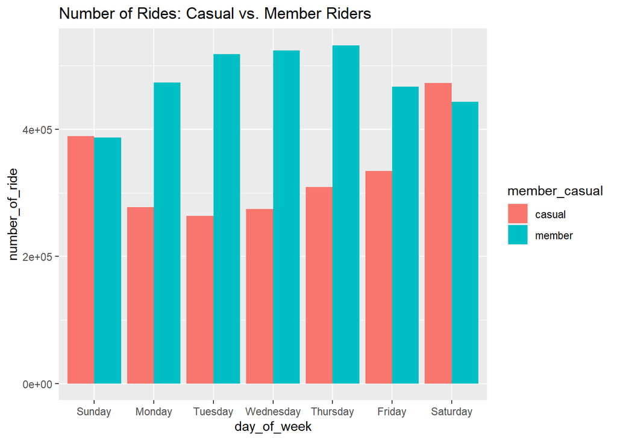

```r
clean_data_trips %>%
    group_by(member_casual, day_of_week) %>%
    summarise(number_of_ride = n(),
avgerage_duration = mean(ride_length))%>%
arrange(member_casual, day_of_week)  %>%
ggplot(aes(x = day_of_week, y = number_of_ride, fill = member_casual)) +
geom_col(position = "dodge") +
labs(title = "Number of Rides: Casual vs. Member Riders")
```

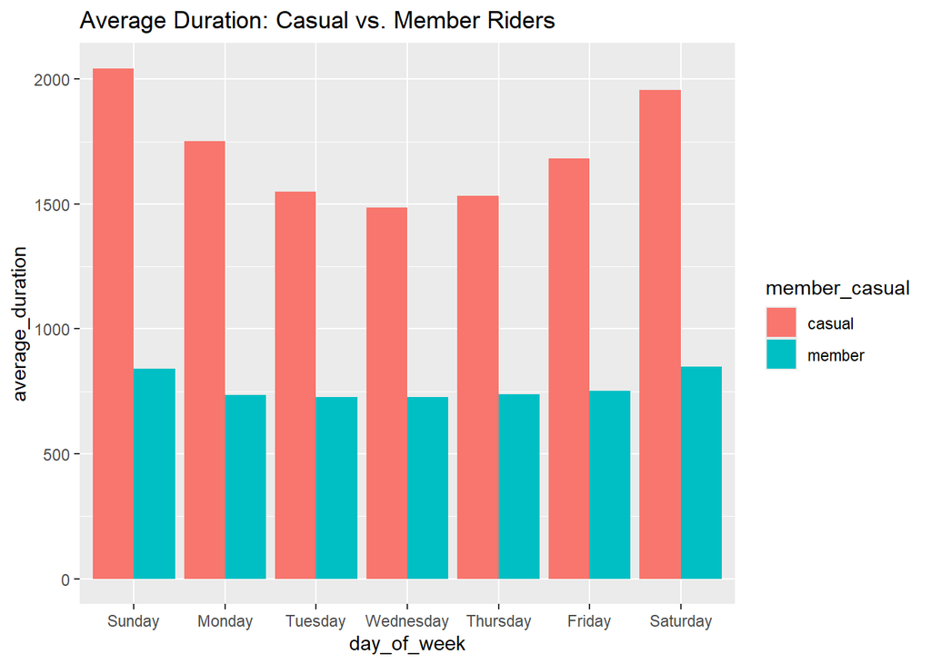

```r
clean_data_trips %>%
  group_by(member_casual, day_of_week) %>%
  summarise(number_of_ride = n()
      ,average_duration = mean(ride_length)) %>%
arrange(member_casual,day_of_week)  %>%
ggplot(aes(x = day_of_week, y = average_duration, fill = member_casual)) +
geom_col(position = "dodge") +
labs(title = "Average Duration: Casual vs. Member Riders")
```